# DATA 698 Final Research Project

Philip Tanofsky

2022-11-13

# Contents

## Abstract

# Introduction

## The Problem

# Literature Review

# Methodology

# Data Collection & Preprocessing

## Data Collection

Citi Bike provides individual bike trip data on a monthly basis available at https://ride.citibikenyc.com/system-data. The September 2022 bike trip data for New York City was downloaded and unzipped. The dataset contains 13 variables for each bike trip originating at a NYC-based location. A note on the system data page indicates trips taken by staff to service or inspect the system have been removed from the dataset. Also, any trips below 60 seconds have also been omitted. With this preprocessing by the data maintainers, the remaining trips are considered to be valid bike trips.

Based on the `started.at` and `ended.at` variables, four variables are derived for each bike trip.

In order to track the bike availability at each docking station, an API call is made to the Citi Bike General Bikeshare Feed (https://github.com/MobilityData/gbfs/blob/master/gbfs.md) for the Station Status JSON every 15 minutes from Monday, October 31 through Sunday, November 14 using a chron script.

The NYC Open Data (free public data published by New York City agencies and partners) provides a GeoJSON file for the polygons defining each neighbhorhood in NYC according for the 2010 Neighborhood Tabulation Areas (NTAs). Each NTA is associated with one of the five NYC boroughs. (https://data.cityofnewyork.us/City-Government/2010-Neighborhood-Tabulation-Areas-NTAs-/cpf4-rkhq)

The elevation of each Citi Bike docking station is determined using the R library `elevatr` based on the latitude and longitude of each station. The elevation is defined in meters above sea level.

## Data Preprocessing

Upon initial inspection of the 3,507,123 bike trips in September 2022, a total of 8,012 entries do not have an `end.station.id` and `end.station.name` listed. Of that count, 3,838 do not contain an `end.lat` and `end.lng` values. These 8,012 without a defined destination docking station will be defined as ‘Abandoned’ meaning the rider did not proper dock the bike. For this purpose, the `end.lat` and `end.lng` will be removed as the abandoned bikes temporarily remove a bike from the bikeshare system. Another rider cannot rent an abandoned bike until the bike is properly docked.

- Building the matrix of surplus by 15 minute interval and station ID
- Overall surplus
- Building the network graph object

# Data Exploration & Analysis

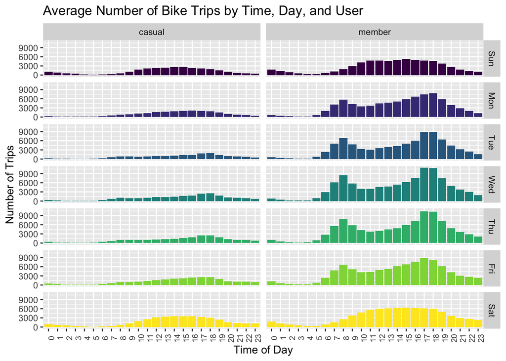

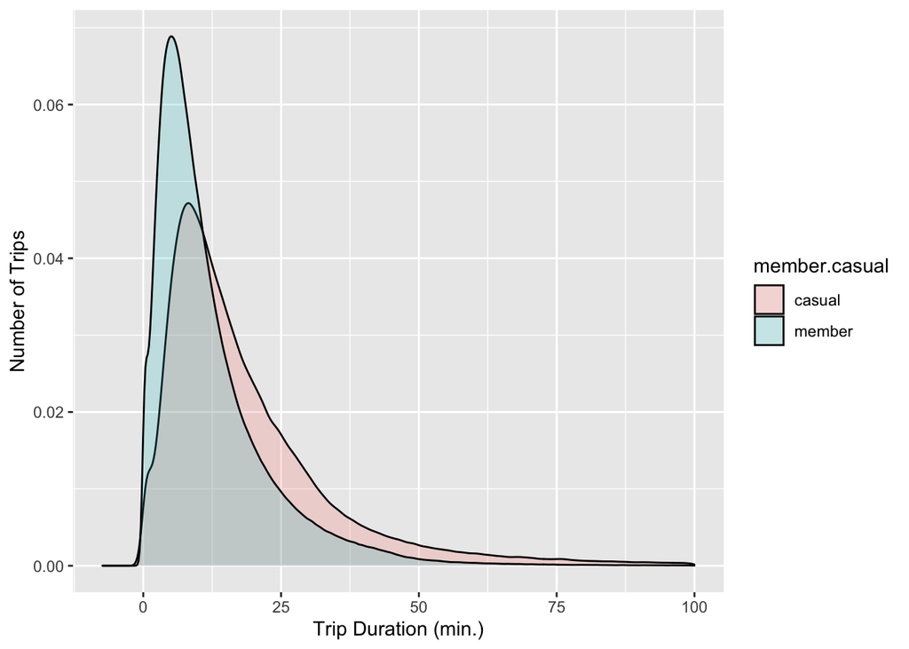

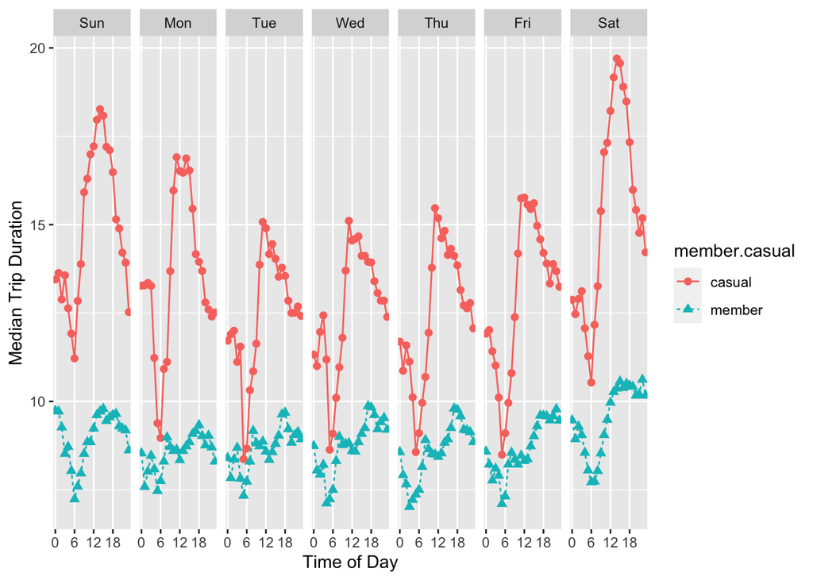

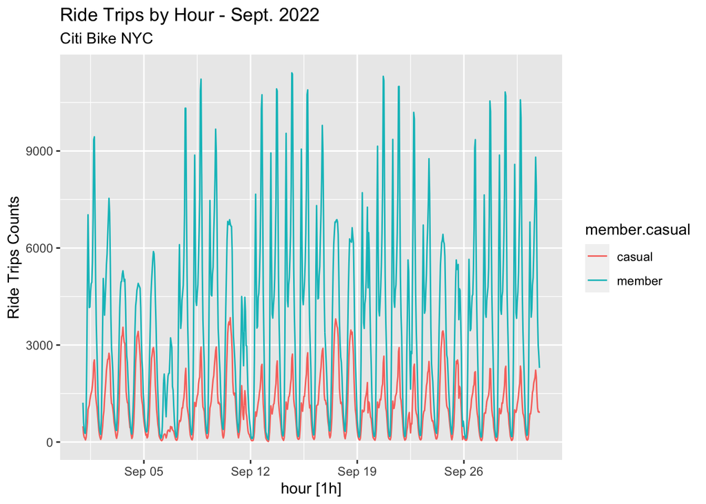

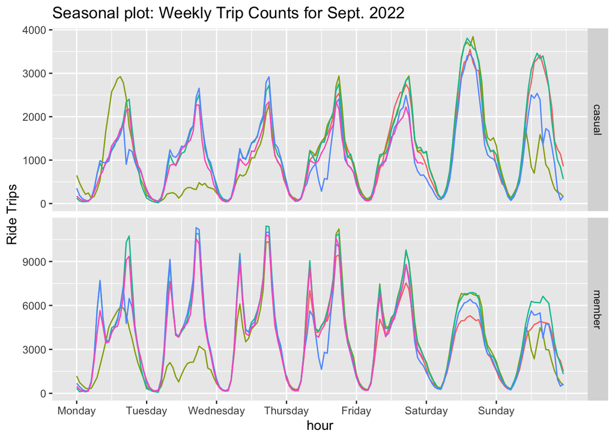

[interactive chart not shown]

There are start_station_id and end_station_id that start with ‘SYS’ with a valid lat/long, so keep them

There are NO starts with JC or HB, but there are ends with JC and HB

For all valid combinations of start to end, there are 472920 combinations

471313 in which the start and the end station IDs are NOT the same

#### Graph object 644->700

```
## $vertices
## + 2/1657 vertices, named, from 22b61ac:
## [1] 2821.05 8428.03
##
## $distance
## [1] 4
```